# Flood Detection Analysis

August 31, 2018

## Flood Detection Analysis

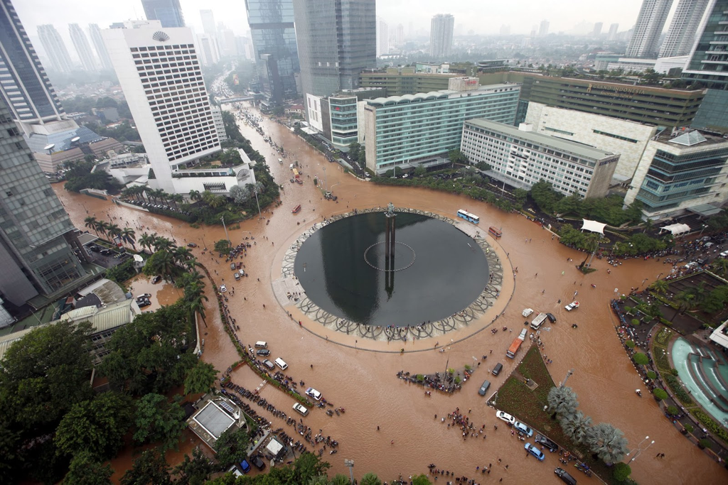

alt text

## Background

Jakarta flooding has become somekind of a tradition, where flood can happen yearly and can go for over 2 weeks on every occurence

Research found that there are a few reasons for the flood:

- high precipitation
- humidity level
- tide level
- land subsidence
- percipitation from neighboring area, based on the water level at Katulampa floodgate

## Problem Statement

Can we predict if flooding is going to happen given below conditions:

1. the weather data
2. Katulampa flood gate water level
3. Flood prediction based on One day before the flood of historical flood data

## Expected Result

To confirm using Random Forest Algorithm, if there is a statistical significance that we are able predict the flood before it happens, based on the weather data, Katulampa water level and H-1 of historical flood data

## Data Sources

- https://www7.ncdc.noaa.gov/CDO/cdoselect.cmd?datasetabbv=GSOD&countryabbv&georegionabbv (available data June 1968-June 2018)
- https://data.go.id/dataset/curah-hujan-dan-hari-hujan-menurut-bulan-dki-jakarta (January 2013-October 2016)
- https://bpbd.jakarta.go.id/waterlevel/ (April 2009-January 2014)
- http://data.jakarta.go.id/group/lingkungan-hidup

Period used: 2013-2016

## Data source from NOAA

Data source sample

```r
flood_data <- read.csv("data/CLEAN DATASET BANJIR.csv", stringsAsFactors = FALSE)
head(flood_data)
```

```
##      STN YEARMODA TEMP DEWP    SLP    STP VISIB WDSP MXSPD  MAX  MIN PRCP
## 1 967450 20130101 81.0 75.1 1008.9 1008.4   4.2  6.0   9.9 89.2 75.9 0.08
## 2 967450 20130102 82.7 75.4 1010.1 1009.7   4.9  3.5   8.0 88.5 76.6 0.00
## 3 967450 20130103 83.6 75.8 1008.7 1008.2   4.2  4.4   9.9 90.7 77.9 0.04
## 4 967450 20130104 78.6 73.4 1008.1 1007.7   4.0  6.8   9.9 86.4 75.6 0.26
## 5 967450 20130105 80.5 74.9 1007.6 1007.2   4.0  5.7  11.1 87.4 75.2 0.20
## 6 967450 20130106 80.3 73.9 1009.1 1008.6   4.2  8.4  12.0 85.6 73.0 0.20
##   FOG RAIN SNOW HAIL THUNDER TORNADO FACT1 FACT2
## 1   0    1    0    0       1       1     0     0
## 2   0    0    0    0       0       0     0     0
## 3   0    1    0    0       0       0     0     0
## 4   0    1    0    0       1       1     0     0
## 5   0    1    0    0       0       0     0     0
## 6   0    1    0    0       0       0     0     0
```

## Data source explanation

Breakdown of the data structure

| CODE | Description |
| --- | --- |
| STN | Station number for the location. |
| YEARMODA | The year, month and day. |
| TEMP | Mean temperature for the day in degrees Fahrenheit to tenths. |
| DEWP | Mean dew point for the day in degrees Fahrenheit to tenths. |
| SLP | Mean sea level pressure for the day in millibars to tenths. |

## Data source explanation

| CODE | Description |
| --- | --- |
| STP | Mean station pressure for the day in millibars to tenths. |
| VISIB | Mean visibility for the day in miles to tenths. |
| WDSP | Mean wind speed for the day in knots to tenths. |
| MXSPD | Maximum sustained wind speed reported for the day in knots to tenths. |
| GUST | Maximum wind gust reported for the day in knots to tenths. |

## Data source explanation

| CODE | Description |
| --- | --- |
| MAX | Maximum temperature reported during the day in Fahrenheit to tenths–time of max temp report varies by country and region, so this will sometimes not be the max for the calendar day. |
| MIN | Minimum temperature reported during the day in Fahrenheit to tenths–time of min temp report varies by country and region, so this will sometimes not be the min for the calendar day. |
| PRCP | Total precipitation (rain and/or melted snow) reported during the day in inches and hundredths. |
| SNDP | Snow depth in inches to tenths–last report for the day if reported more than once. |
| FRSHTT | Indicators for the occurrence during the day of: Fog ('F' - 1st digit). Rain or Drizzle ('R' - 2nd digit). Snow or Ice Pellets ('S' - 3rd digit). Hail ('H' - 4th digit). Thunder ('T' - 5th digit). Tor… |

## ETL the data

```r
summary(flood_data[,1:10])
```

```
##       STN            YEARMODA             TEMP            DEWP
##  Min.   :967450   Min.   :20130101   Min.   :75.20   Min.   :64.10
##  1st Qu.:967450   1st Qu.:20140330   1st Qu.:82.70   1st Qu.:73.50
##  Median :967450   Median :20150310   Median :84.00   Median :74.50
##  Mean   :967450   Mean   :20146589   Mean   :83.73   Mean   :74.26
##  3rd Qu.:967450   3rd Qu.:20160130   3rd Qu.:85.00   3rd Qu.:75.40
##  Max.   :967450   Max.   :20161231   Max.   :88.60   Max.   :78.60
##       SLP            STP           VISIB            WDSP
##  Min.   :1006   Min.   :1006   Min.   :3.000   Min.   : 0.400
##  1st Qu.:1009   1st Qu.:1009   1st Qu.:4.000   1st Qu.: 1.900
##  Median :1010   Median :1010   Median :4.200   Median : 2.500
##  Mean   :1010   Mean   :1010   Mean   :4.228   Mean   : 2.642
##  3rd Qu.:1011   3rd Qu.:1011   3rd Qu.:4.300   3rd Qu.: 3.300
##  Max.   :1015   Max.   :1014   Max.   :5.600   Max.   :12.400
##      MXSPD            MAX
##  Min.   : 2.90   Min.   : 76.60
##  1st Qu.: 5.10   1st Qu.: 88.90
##  Median : 6.00   Median : 90.70
##  Mean   : 6.69   Mean   : 90.37
##  3rd Qu.: 8.00   3rd Qu.: 92.10
##  Max.   :28.00   Max.   :105.10
```

## ETL the data

```r
summary(flood_data[,11:20])
```

```
##       MIN             PRCP             FOG         RAIN             SNOW
##  Min.   :61.20   Min.   :0.0000   Min.   :0   Min.   :0.0000   Min.   :0
##  1st Qu.:77.00   1st Qu.:0.0000   1st Qu.:0   1st Qu.:0.0000   1st Qu.:0
##  Median :78.10   Median :0.0000   Median :0   Median :0.0000   Median :0
##  Mean   :77.91   Mean   :0.1293   Mean   :0   Mean   :0.2565   Mean   :0
##  3rd Qu.:79.20   3rd Qu.:0.0100   3rd Qu.:0   3rd Qu.:1.0000   3rd Qu.:0
##  Max.   :82.00   Max.   :8.4300   Max.   :0   Max.   :1.0000   Max.   :0
##       HAIL              THUNDER          TORNADO          FACT1
##  Min.   :0.0000000   Min.   :0.0000   Min.   :0.0000   Normal:1025
##  1st Qu.:0.0000000   1st Qu.:0.0000   1st Qu.:0.0000   Flood : 203
##  Median :0.0000000   Median :0.0000   Median :0.0000
##  Mean   :0.0008143   Mean   :0.1303   Mean   :0.1303
##  3rd Qu.:0.0000000   3rd Qu.:0.0000   3rd Qu.:0.0000
##  Max.   :1.0000000   Max.   :1.0000   Max.   :1.0000
##     FACT2
##  Normal:877
##  H-1   : 68
##  NA's  :283
##
##
##
```

## Facts about the data

Our source of data consist of flood (Flood) and Normal (no flooding)

```r
table(flood_data$FACT1)
```

```
##
## Normal  Flood
##   1025    203
```

```r
min(flood_data$YEARMODA)
```

```
## [1] 20130101
```

```r
max(flood_data$YEARMODA)
```

```
## [1] 20161231
```

## Data preparation

We remove unnecessary data (Station, date, another set of prediction, fog, snow and hail)

```r
flood_data <- subset(flood_data, select = -c(STN, YEARMODA, FACT2, FOG, SNOW, HAIL))
```

Also, we randomize from time series to avoid uneven spread data (sample() function)

```r
flood_data <- flood_data[sample(nrow(flood_data)),]
```

## Data Preparation

We split the data into training data (80%) and test data (20%)

```r
flood_data_intrain <- sample(nrow(flood_data), nrow(flood_data)*0.8)
flood_data_train <- flood_data[flood_data_intrain, ]
flood_data_test <- flood_data[-flood_data_intrain, ]
```

```r
table(flood_data_train$FACT1)
```

```
##
## Normal  Flood
##    837    145
```

```r
prop.table(table(flood_data_train$FACT1))
```

```
##
##    Normal     Flood
## 0.8523422 0.1476578
```

```r
table(flood_data_test$FACT1)
```

```
##
## Normal  Flood
##    188     58
```

```r
prop.table(table(flood_data_test$FACT1))
```

```
##
##    Normal     Flood
## 0.7642276 0.2357724
```

## Random forest function

Random forest implementation, with 4 mtry variables and 6 ntree variables

```r
rdsdata1 <- "data/randomforest1.rds"

# conditional. Remove rdsdata file to run this logic
if (!file.exists(rdsdata1)) {

  # Manual Search
  mtry_base <- sqrt(ncol(flood_data_train))
  seed <- 9
  metric <- "Accuracy"
  tunegrid <- expand.grid(.mtry=c(mtry_base ^ 0, mtry_base ^ 1, mtry_base * 2, mtry_base ^ 2))
  modellist1 <- list()
  repeats <- 10
  method <- "repeatedcv"

  for (ntree in c(25, 50, 100, 200, 500, 1000)) {
    control <- trainControl(method=method, number=10, repeats=repeats)
    flood_forest_ntree <- train(FACT1~., data=flood_data_train, method="rf", metric=metric, tuneGrid=tunegrid, trControl=control, ntree=ntree)
    key <- toString(ntree)
    modellist1[[key]] <- flood_forest_ntree
  }
  saveRDS(modellist1, file = rdsdata1)

} else {
  modellist1 <-readRDS(rdsdata1)
}


#ctrl <- trainControl(method="repeatedcv", number=5, repeats=3)
#flood_data_forest <- train(FACT1 ~ ., data=flood_data_train, method="rf", trControl = ctrl)
```

## What is Mtry and ntree

### Mtry

Number of variables randomly sampled as candidates at each split.

### Ntree

Number of trees to grow.

## Result of the Random Forest Tests

```r
results <- resamples(modellist1)

summary(results)
```

```
##
## Call:
## summary.resamples(object = results)
##
## Models: 25, 50, 100, 200, 500, 1000
## Number of resamples: 100
##
## Accuracy
##           Min.   1st Qu.    Median      Mean   3rd Qu.      Max. NA's
## 25   0.8367347 0.8484848 0.8556701 0.8527579 0.8571429 0.8673469    0
## 50   0.8144330 0.8453608 0.8571429 0.8525571 0.8604342 0.8865979    0
## 100  0.8383838 0.8484848 0.8520775 0.8521615 0.8571429 0.8673469    0
## 200  0.8144330 0.8383838 0.8484848 0.8530742 0.8673469 0.9081633    0
## 500  0.8080808 0.8469388 0.8520775 0.8534013 0.8659794 0.8877551    0
## 1000 0.8163265 0.8469388 0.8571429 0.8535672 0.8663213 0.8865979    0
##
## Kappa
##             Min.    1st Qu.     Median        Mean   3rd Qu.      Max.
## 25   -0.01962158 0.00000000 0.00000000 0.014357661 0.0000000 0.1165049
## 50   -0.06854345 0.06382979 0.14038385 0.129944855 0.1946903 0.3508197
## 100  -0.01941748 0.00000000 0.00000000 0.005137561 0.0000000 0.1165049
## 200  -0.06779661 0.02296702 0.11469545 0.129419249 0.1977737 0.4878049
## 500  -0.06814310 0.00000000 0.09224599 0.101567701 0.1723314 0.3811711
## 1000 -0.06779661 0.00000000 0.10026249 0.103246396 0.1808511 0.3734586
##      NA's
## 25      0
## 50      0
## 100     0
## 200     0
## 500     0
## 1000    0
```

## Plotting the result

Bigger Kappa is better. The Kappa is below 20%, so it's safe to say that the quality of accuracy is not good enough

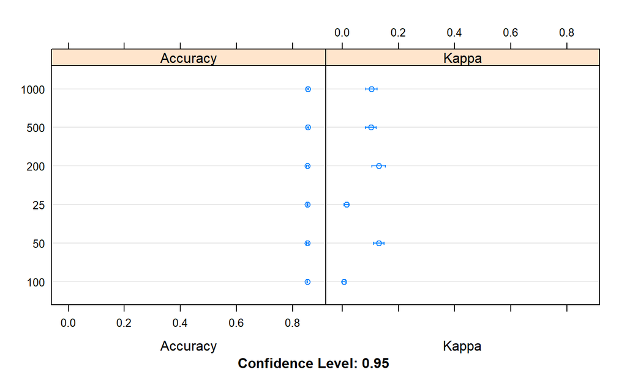

```r
dotplot(results)
```

```r
flood_data_forest <- modellist1$`200`
```

## Understanding Kappa

The Kappa statistic (or value) is a metric that compares an Observed Accuracy with an Expected Accuracy (random chance).

Kappa = (observed accuracy - expected accuracy)/(1 - expected accuracy)

- <0 as indicating no agreement
- 0.00–0.20 as slight,
- 0.21–0.40 as fair,
- 0.41–0.60 as moderate,
- 0.61–0.80 as substantial, and
- 0.81–1 as almost perfect agreement.

## Random forest

Result of the random forest function

```r
flood_data_forest
```

```
## Random Forest
##
## 982 samples
##  13 predictor
##   2 classes: 'Normal', 'Flood'
##
## No pre-processing
## Resampling: Cross-Validated (10 fold, repeated 10 times)
## Summary of sample sizes: 883, 883, 884, 885, 883, 884, ...
## Resampling results across tuning parameters:
##
##   mtry       Accuracy   Kappa
##    1.000000  0.8516488  0.0005791631
##    3.741657  0.8529691  0.1116864726
##    7.483315  0.8530742  0.1294192491
##   14.000000  0.8489895  0.1340316280
##
## Accuracy was used to select the optimal model using the largest value.
## The final value used for the model was mtry = 7.483315.
```

## Prediction based on the formula

We try to see the result of the prediction

```r
flood_rf <- table(predict(flood_data_forest, flood_data_test[,-14]), flood_data_test[,14])
summary(flood_data_test[14])
```

```
##     FACT1
##  Normal:188
##  Flood : 58
```

```r
flood_rf
```

```
##
##          Normal Flood
##   Normal    184    54
##   Flood       4     4
```

Accuracy is:

```r
(flood_rf["Normal", "Normal"] + flood_rf["Flood", "Flood"]) / sum(flood_rf)
```

```
## [1] 0.7642276
```

## Variable Importance

```r
varImp(flood_data_forest)
```

```
## rf variable importance
##
##           Overall
## DEWP    100.00000
## TEMP     90.94879
## MIN      89.76756
## MAX      81.93874
## WDSP     78.00620
## STP      73.18112
## SLP      67.71502
## VISIB    47.71065
## MXSPD    37.66857
## PRCP     32.71868
## RAIN      2.61155
## THUNDER   0.02213
## TORNADO   0.00000
```

## What if we add Flood Gate Data

We found data of water level in the Katulampa water gate

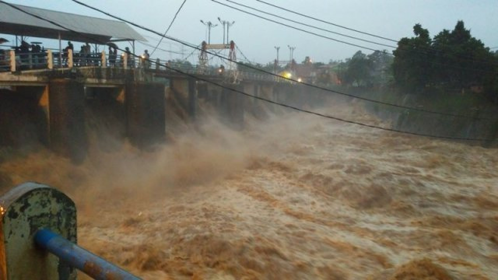

alt text

```r
flood_data <- read.csv("data/CLEAN DATASET BANJIR2.csv", stringsAsFactors = FALSE)
```

```r
summary(flood_data)
```

```
##       STN            YEARMODA             TEMP            DEWP
##  Min.   :967450   Min.   :20130101   Min.   :76.30   Min.   :67.60
##  1st Qu.:967450   1st Qu.:20130312   1st Qu.:82.50   1st Qu.:73.95
##  Median :967450   Median :20130605   Median :84.10   Median :74.70
##  Mean   :967450   Mean   :20130813   Mean   :83.57   Mean   :74.51
##  3rd Qu.:967450   3rd Qu.:20130920   3rd Qu.:84.90   3rd Qu.:75.40
##  Max.   :967450   Max.   :20140109   Max.   :88.60   Max.   :78.20
##       SLP            STP           VISIB            WDSP
##  Min.   :1006   Min.   :1006   Min.   :3.600   Min.   : 0.400
##  1st Qu.:1009   1st Qu.:1008   1st Qu.:4.300   1st Qu.: 1.900
##  Median :1010   Median :1009   Median :4.400   Median : 2.600
##  Mean   :1010   Mean   :1009   Mean   :4.418   Mean   : 2.886
##  3rd Qu.:1011   3rd Qu.:1010   3rd Qu.:4.600   3rd Qu.: 3.550
##  Max.   :1013   Max.   :1012   Max.   :5.600   Max.   :12.400
##      MXSPD             MAX             MIN             PRCP
##  Min.   : 2.900   Min.   :80.60   Min.   :72.50   Min.   :0.0000
##  1st Qu.: 5.100   1st Qu.:88.50   1st Qu.:76.10   1st Qu.:0.0000
##  Median : 7.000   Median :90.70   Median :77.20   Median :0.0000
##  Mean   : 7.325   Mean   :90.24   Mean   :77.29   Mean   :0.1239
##  3rd Qu.: 8.900   3rd Qu.:92.10   3rd Qu.:78.70   3rd Qu.:0.0000
##  Max.   :28.000   Max.   :95.40   Max.   :81.50   Max.   :3.0700
##       FOG         RAIN            SNOW        HAIL      THUNDER
##  Min.   :0   Min.   :0.000   Min.   :0   Min.   :0   Min.   :0.0000
##  1st Qu.:0   1st Qu.:0.000   1st Qu.:0   1st Qu.:0   1st Qu.:0.0000
##  Median :0   Median :0.000   Median :0   Median :0   Median :0.0000
##  Mean   :0   Mean   :0.214   Mean   :0   Mean   :0   Mean   :0.1587
##  3rd Qu.:0   3rd Qu.:0.000   3rd Qu.:0   3rd Qu.:0   3rd Qu.:0.0000
##  Max.   :0   Max.   :1.000   Max.   :0   Max.   :0   Max.   :1.0000
##     TORNADO         tinggi_air         FACT1            FACT2
##  Min.   :0.0000   Min.   : 10.00   Min.   :0.0000   Min.   :0.00000
##  1st Qu.:0.0000   1st Qu.: 20.00   1st Qu.:0.0000   1st Qu.:0.00000
##  Median :0.0000   Median : 29.58   Median :0.0000   Median :0.00000
##  Mean   :0.1587   Mean   : 30.12   Mean   :0.1808   Mean   :0.05904
##  3rd Qu.:0.0000   3rd Qu.: 37.08   3rd Qu.:0.0000   3rd Qu.:0.00000
##  Max.   :1.0000   Max.   :114.58   Max.   :1.0000   Max.   :1.00000
```

## ETL the data

```r
summary(flood_data[ ,19:20])
```

```
##    tinggi_air        FACT1
##  Min.   : 10.00   Normal:222
##  1st Qu.: 20.00   Flood : 49
##  Median : 29.58
##  Mean   : 30.12
##  3rd Qu.: 37.08
##  Max.   :114.58
```

## Total source data comparison

```r
table(flood_data$FACT1)
```

```
##
## Normal  Flood
##    222     49
```

```
##
##    Normal     Flood
## 0.8148148 0.1851852
```

```
##
##    Normal     Flood
## 0.8363636 0.1636364
```

## Random forest function

We run the same random forest, with 4 variation of mtry and 6 variation of ntree

```r
rdsdata2 <- "data/randomforest2.rds"

# conditional. Remove rdsdata file to run this logic
if (!file.exists(rdsdata2)) {

  # Manual Search
  mtry_base <- sqrt(ncol(flood_data_train))
  seed <- 9
  metric <- "Accuracy"
  tunegrid <- expand.grid(.mtry=c(mtry_base ^ 0, mtry_base ^ 1, mtry_base * 2, mtry_base ^ 2))
  modellist2 <- list()
  repeats <- 10
  method <- "repeatedcv"

  for (ntree in c(25, 50, 100, 200, 500, 1000)) {
    control <- trainControl(method=method, number=10, repeats=repeats)
    flood_forest_ntree <- train(FACT1~., data=flood_data_train, method="rf", metric=metric, tuneGrid=tunegrid, trControl=control, ntree=ntree)
    key <- toString(ntree)
    modellist2[[key]] <- flood_forest_ntree
  }
  saveRDS(modellist2, file = rdsdata2)

} else {
  modellist2 <-readRDS(rdsdata2)
}


#ctrl <- trainControl(method="repeatedcv", number=5, repeats=3)
#flood_data_forest <- train(FACT1 ~ ., data=flood_data_train, method="rf", trControl = ctrl)
```

## Result of Random Forest

```r
results <- resamples(modellist2)

summary(results)
```

```
##
## Call:
## summary.resamples(object = results)
##
## Models: 25, 50, 100, 200, 500, 1000
## Number of resamples: 100
##
## Accuracy
##           Min.   1st Qu.    Median      Mean   3rd Qu.      Max. NA's
## 25   0.7272727 0.8181818 0.8636364 0.8616507 0.9090909 1.0000000    0
## 50   0.7272727 0.8181818 0.8571429 0.8563872 0.9047619 1.0000000    0
## 100  0.7272727 0.8181818 0.8636364 0.8640316 0.9047619 0.9545455    0
## 200  0.7142857 0.8181818 0.8636364 0.8629992 0.9047619 1.0000000    0
## 500  0.6666667 0.8181818 0.8571429 0.8555327 0.9047619 1.0000000    0
## 1000 0.7272727 0.8181818 0.8636364 0.8609194 0.9047619 0.9545455    0
##
## Kappa
##            Min.   1st Qu.    Median      Mean   3rd Qu.      Max. NA's
## 25   -0.1578947 0.2447711 0.4615385 0.4171671 0.6118421 1.0000000    0
## 50   -0.1379310 0.2299742 0.3888889 0.3837682 0.5939542 1.0000000    0
## 100  -0.1379310 0.2380520 0.3529412 0.3537457 0.4695122 0.8607595    0
## 200  -0.1290323 0.3225806 0.4615385 0.4322177 0.6111111 1.0000000    0
## 500  -0.1290323 0.2222222 0.3720145 0.3679473 0.5822785 1.0000000    0
## 1000 -0.1290323 0.2365900 0.4615385 0.3874056 0.5939542 0.8307692    0
```

## Plot data of the test

Kappa: https://stats.stackexchange.com/a/82187

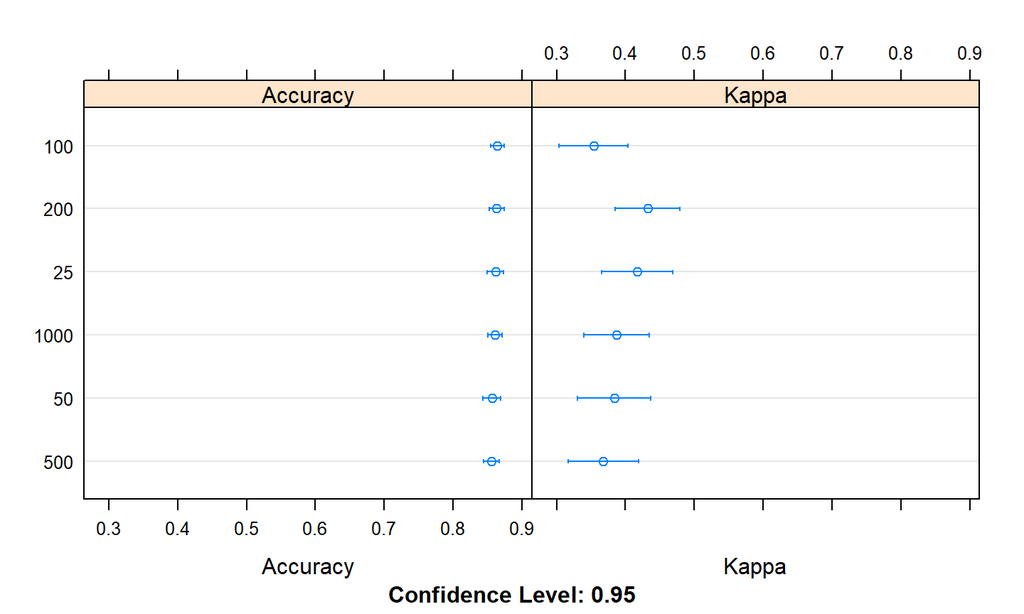

```r
dotplot(results)
```

```r
flood_data_forest <- modellist2$`50`
```

## Random forest test result

Result of the random forest function

```r
flood_data_forest
```

```
## Random Forest
##
## 216 samples
##  14 predictor
##   2 classes: 'Normal', 'Flood'
##
## No pre-processing
## Resampling: Cross-Validated (10 fold, repeated 10 times)
## Summary of sample sizes: 194, 195, 195, 194, 193, 195, ...
## Resampling results across tuning parameters:
##
##   mtry       Accuracy   Kappa
##    1.000000  0.8475701  0.08248069
##    3.872983  0.8496810  0.30110724
##    7.745967  0.8563872  0.38376821
##   15.000000  0.8524337  0.38681053
##
## Accuracy was used to select the optimal model using the largest value.
## The final value used for the model was mtry = 7.745967.
```

## Prediction based on the formula

We try to see the result of the prediction

```r
flood_rf <- table(predict(flood_data_forest, flood_data_test[,-15]), flood_data_test[,15])
flood_rf
```

```
##
##          Normal Flood
##   Normal     46     0
##   Flood       0     9
```

Accuracy is:

```r
(flood_rf["Normal", "Normal"] + flood_rf["Flood", "Flood"]) / sum(flood_rf)
```

```
## [1] 1
```

## Conclusion

From this data, the effect of adding Katulampa flood gate data is one contributing factor for the accuracy of the prediction

```r
varImp(flood_data_forest)
```

```
## rf variable importance
##
##            Overall
## TEMP       100.000
## MIN         98.106
## STP         78.685
## tinggi_air  77.055
## SLP         63.815
## MAX         36.300
## WDSP        34.785
## MXSPD       28.218
## VISIB       19.734
## DEWP        18.323
## PRCP         9.959
## TORNADO      4.707
## RAIN         3.902
## THUNDER      0.000
```

## How about predicting 1 Day before?

```r
flood_data <- read.csv("data/CLEAN DATASET BANJIR2.csv", stringsAsFactors = FALSE)
head(flood_data[,19:21], 20)
```

```
##    tinggi_air FACT1 FACT2
## 1    30.83333     0     0
## 2    16.25000     0     0
## 3    10.00000     0     0
## 4    35.00000     0     0
## 5    38.33333     0     0
## 6    43.75000     0     0
## 7    36.25000     0     0
## 8    51.25000     0     1
## 9    80.83333     1     0
## 10   57.91667     1     0
## 11   32.50000     0     0
## 12   50.41667     0     0
## 13   56.66667     0     0
## 14  108.33333     0     1
## 15  114.58333     1     0
## 16   80.00000     1     0
## 17   80.00000     1     0
## 18   57.08333     1     0
## 19   56.66667     1     0
## 20   58.75000     1     0
```

## ETL the data

```r
summary(flood_data[ ,19:21])
```

```
##    tinggi_air        FACT1        FACT2
##  Min.   : 10.00   Normal:222   Normal:255
##  1st Qu.: 20.00   Flood : 49   H-1   : 16
##  Median : 29.58
##  Mean   : 30.12
##  3rd Qu.: 37.08
##  Max.   :114.58
```

## Total source data comparison

```r
table(flood_data$FACT2)
```

```
##
## Normal    H-1
##    255     16
```

```
##
##     Normal        H-1
## 0.93981481 0.06018519
```

```
##
##     Normal        H-1
## 0.94545455 0.05454545
```

## Random forest function

We run the same random forest, with 4 variation of mtry and 6 variation of ntree

```r
rdsdata3 <- "data/randomforest3.rds"

# conditional. Remove rdsdata file to run this logic
if (!file.exists(rdsdata3)) {

  # Manual Search
  mtry_base <- sqrt(ncol(flood_data_train))
  seed <- 9
  metric <- "Accuracy"
  tunegrid <- expand.grid(.mtry=c(mtry_base ^ 0, mtry_base ^ 1, mtry_base * 2, mtry_base ^ 2))
  modellist3 <- list()
  repeats <- 10
  method <- "repeatedcv"

  for (ntree in c(25, 50, 100, 200, 500, 1000)) {
    control <- trainControl(method=method, number=10, repeats=repeats)
    flood_forest_ntree <- train(FACT2~., data=flood_data_train, method="rf", metric=metric, tuneGrid=tunegrid, trControl=control, ntree=ntree)
    key <- toString(ntree)
    modellist3[[key]] <- flood_forest_ntree
  }
  saveRDS(modellist3, file = rdsdata3)

} else {
  modellist3 <-readRDS(rdsdata3)
}


#ctrl <- trainControl(method="repeatedcv", number=5, repeats=3)
#flood_data_forest <- train(FACT1 ~ ., data=flood_data_train, method="rf", trControl = ctrl)
```

## Result of Random Forest

```r
results <- resamples(modellist3)

summary(results)
```

```
##
## Call:
## summary.resamples(object = results)
##
## Models: 25, 50, 100, 200, 500, 1000
## Number of resamples: 100
##
## Accuracy
##           Min.   1st Qu.   Median      Mean  3rd Qu.      Max. NA's
## 25   0.9090909 0.9090909 0.952381 0.9356409 0.952381 0.9545455    0
## 50   0.9090909 0.9090909 0.952381 0.9356051 0.952381 0.9545455    0
## 100  0.9090909 0.9090909 0.952381 0.9356945 0.952381 0.9545455    0
## 200  0.9090909 0.9090909 0.952381 0.9355872 0.952381 0.9545455    0
## 500  0.9090909 0.9090909 0.952381 0.9356766 0.952381 0.9545455    0
## 1000 0.9090909 0.9090909 0.952381 0.9356409 0.952381 0.9545455    0
##
## Kappa
##      Min. 1st Qu. Median Mean 3rd Qu. Max. NA's
## 25      0       0      0    0       0    0    0
## 50      0       0      0    0       0    0    0
## 100     0       0      0    0       0    0    0
## 200     0       0      0    0       0    0    0
## 500     0       0      0    0       0    0    0
## 1000    0       0      0    0       0    0    0
```

## Plot data of the test

```r
flood_data_forest <- modellist3$`1000`
```

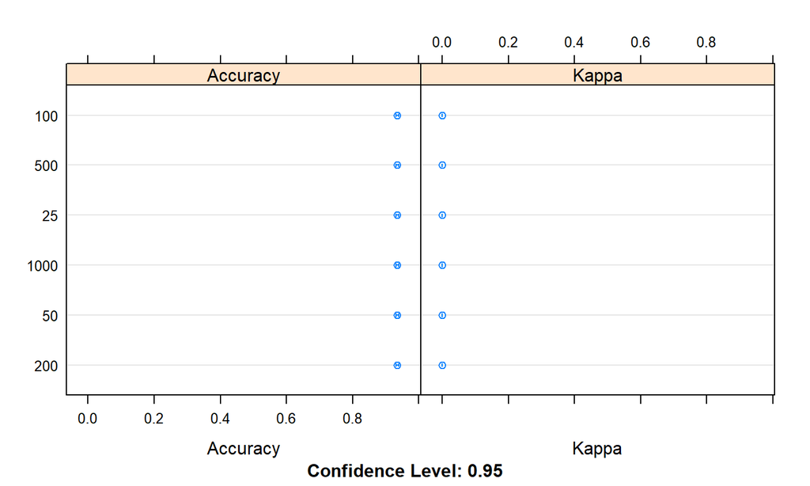

```r
dotplot(results)
```

## Random forest test result

Result of the random forest function. You can see that the Kappa is very bad (around zero). The information here is useless.

```r
flood_data_forest
```

```
## Random Forest
##
## 216 samples
##  14 predictor
##   2 classes: 'Normal', 'H-1'
##
## No pre-processing
## Resampling: Cross-Validated (10 fold, repeated 10 times)
## Summary of sample sizes: 194, 194, 195, 194, 195, 195, ...
## Resampling results across tuning parameters:
##
##   mtry       Accuracy   Kappa
##    1.000000  0.9356409   0.000000000
##    3.872983  0.9342556  -0.001500000
##    7.745967  0.9323725  -0.003645161
##   15.000000  0.9281084  -0.007390583
##
## Accuracy was used to select the optimal model using the largest value.
## The final value used for the model was mtry = 1.
```

## Prediction based on the formula

We try to see the result of the prediction

```r
summary(flood_data_test[14:15])
```

```
##    tinggi_air       FACT2
##  Min.   :10.00   Normal:52
##  1st Qu.:20.00   H-1   : 3
##  Median :25.83
##  Mean   :29.57
##  3rd Qu.:36.39
##  Max.   :80.00
```

## Prediction based on the formula

We try to see the result of the prediction

```r
flood_rf <- table(predict(flood_data_forest, flood_data_test[,-15]), flood_data_test[,15])
flood_rf
```

```
##
##          Normal H-1
##   Normal     52   2
##   H-1         0   1
```

Accuracy is:

```r
(flood_rf["Normal", "Normal"] + flood_rf["H-1", "H-1"]) / sum(flood_rf)
```

```
## [1] 0.9636364
```

## Conclusion

The result is inconclusive. We think that the lack amount of data doesn't help either. Kappa is below 0.10, and even negative 0.00, thus indicating that the confidence level is really bad. We can't use this result.

Slide and R code available at https://github.com/natali/berkeleycapstone

```r
varImp(flood_data_forest)
```

```
## rf variable importance
##
##            Overall
## tinggi_air 100.000
## DEWP        98.884
## MAX         86.807
## WDSP        85.602
## SLP         78.836
## TEMP        78.462
## STP         75.818
## MIN         72.490
## VISIB       66.421
## MXSPD       56.533
## PRCP        36.333
## THUNDER      1.571
## RAIN         1.398
## TORNADO      0.000
```